# Sensitivity of LBSPR to life history parameters $M/k$ and $L_{inf}$. The case of European anchovy in area 9a South

Margarita Rincón

15/10/2020

## LB-SPR Análisis de Sensibilidad

Empezamos cargando la librería.

```r
library(LBSPR)
```

Los datos del ciclo vital recogidos de la literatura son (en base a LH Invariants analysis):

${M/k}^{LIT}=1.3/0.9$=1.44

$L_{inf}^{LIT}$=18.95 (k y $L_{inf}$ de Bellido et al. 2000)

M = 1.3 (Razonamiento en WKPELA 2018 report, uso M para la edad 1 $M_1$)

L50=11.2 (Millán 1999)

L95=13.3 (Millán 1999)

Con la información anterior creamos un objecto "LB_pars".

```r
MK<-1.44
LINF<-18.95
Hke1Pars <- new("LB_pars")
```

```
## A blank LB_pars object created
```

```
## Default values have been set for some parameters
```

```r
Hke1Pars@Linf <- 18.95
Hke1Pars@L50 <- 11.2
Hke1Pars@L95 <- 13.3
Hke1Pars@MK <- 1.44
Hke1Pars@M <- 1.3
Hke1Pars@L_units <- "cm"
```

Para poder aplicar el método necesitamos leer el archivo csv con las frecuencias de tallas y crear con dicha información un objecto "LB_lengths".

```r
HkeLenFreq1 <- new("LB_lengths", LB_pars=Hke1Pars, file="lengthfreq_anchovy_fv.csv", dataType="freq", header=TRUE)
HkeLenFreq1@L_units <- Hke1Pars@L_units
```

A partir de la informacón creada ya podemos aplicar nuestro modelo.

El *ESCENARIO DE REFERENCIA* es el que utiliza los parámetros descritos con anterioridad es decir el que usa ${M/k}^{LIT}$ y $L_{inf}^{LIT}$. Los resultados derivados de modificaciones en los valores de $L_{inf}$ y ${M/k}$ se compararan siempre con este escenario que es el que usaríamos en caso de no estar interesados en ver la sensibilidad del método a la correcta especificación de los mismos.

```r
Fit1 <- LBSPRfit(Hke1Pars, HkeLenFreq1)
```

[output not shown]

[output not shown]

[output not shown]

[output not shown]

[output not shown]

[output not shown]

[output not shown]

[output not shown]

[output not shown]

[output not shown]

[output not shown]

[output not shown]

[output not shown]

[output not shown]

[output not shown]

[output not shown]

[output not shown]

[output not shown]

[output not shown]

[output not shown]

[output not shown]

[output not shown]

[output not shown]

[output not shown]

[output not shown]

[output not shown]

[output not shown]

[output not shown]

[output not shown]

[output not shown]

[output not shown]

[output not shown]

[output not shown]

[output not shown]

En las siguientes secciones vemos los resultamos considerando modificaciones de dichos parámetros.

## ESCENARIOS MODIFICADOS USANDO LOS DIFERENTES VALORES PARA EL PARÁMETRO @MK

1. Primero infraestimando (${M/k}^{LIT}$ multiplicado por 0.75):

```r
Hke1ParsMK <-Hke1Pars
Hke1ParsMK@MK <- 0.75*MK


HkeLenFreq1MK <- new("LB_lengths", LB_pars=Hke1ParsMK, file="lengthfreq_anchovy_fv.csv", dataType="freq", header=TRUE)
HkeLenFreq1MK@L_units <- Hke1ParsMK@L_units


Fit1MK <- LBSPRfit(Hke1ParsMK, HkeLenFreq1MK)
```

[output not shown]

[output not shown]

[output not shown]

[output not shown]

[output not shown]

[output not shown]

[output not shown]

[output not shown]

[output not shown]

[output not shown]

[output not shown]

[output not shown]

[output not shown]

[output not shown]

[output not shown]

[output not shown]

[output not shown]

[output not shown]

[output not shown]

[output not shown]

[output not shown]

[output not shown]

[output not shown]

[output not shown]

[output not shown]

[output not shown]

[output not shown]

[output not shown]

[output not shown]

[output not shown]

[output not shown]

[output not shown]

[output not shown]

[output not shown]

2. Segundo sobrestimando (${M/k}^{LIT}$ multiplicado por 1.25):

```r
Hke2ParsMK <-Hke1Pars
Hke2ParsMK@MK <- 1.25*MK


HkeLenFreq2MK <- new("LB_lengths", LB_pars=Hke2ParsMK, file="lengthfreq_anchovy_fv.csv", dataType="freq", header=TRUE)
HkeLenFreq2MK@L_units <- Hke2ParsMK@L_units


Fit2MK <- LBSPRfit(Hke2ParsMK, HkeLenFreq2MK)
```

[output not shown]

[output not shown]

[output not shown]

[output not shown]

[output not shown]

[output not shown]

[output not shown]

[output not shown]

[output not shown]

[output not shown]

[output not shown]

[output not shown]

[output not shown]

[output not shown]

[output not shown]

[output not shown]

[output not shown]

[output not shown]

[output not shown]

[output not shown]

[output not shown]

[output not shown]

[output not shown]

[output not shown]

[output not shown]

[output not shown]

[output not shown]

[output not shown]

[output not shown]

[output not shown]

[output not shown]

[output not shown]

[output not shown]

[output not shown]

3. Tercero usando el valor por defecto de 1.5.

```r
Hke3ParsMK <-Hke1Pars
Hke3ParsMK@MK <- 1.5

HkeLenFreq3MK <- new("LB_lengths", LB_pars=Hke3ParsMK, file="lengthfreq_anchovy_fv.csv", dataType="freq", header=TRUE)
HkeLenFreq3MK@L_units <- Hke3ParsMK@L_units


Fit3MK <- LBSPRfit(Hke3ParsMK, HkeLenFreq3MK)
```

[output not shown]

[output not shown]

[output not shown]

[output not shown]

[output not shown]

[output not shown]

[output not shown]

[output not shown]

[output not shown]

[output not shown]

[output not shown]

[output not shown]

[output not shown]

[output not shown]

[output not shown]

[output not shown]

[output not shown]

[output not shown]

[output not shown]

[output not shown]

[output not shown]

[output not shown]

[output not shown]

[output not shown]

[output not shown]

[output not shown]

[output not shown]

[output not shown]

[output not shown]

[output not shown]

[output not shown]

[output not shown]

[output not shown]

[output not shown]

## ESCENARIOS MODIFICADOS USANDO LOS DIFERENTES VALORES PARA EL PARÁMETRO @Linf

1. Primero infraestimando ($L_{inf}^{LIT}$ multiplicado por 0.75):

```r
Hke1ParsLinf <-Hke1Pars
Hke1ParsLinf@Linf <- 0.75*LINF

HkeLenFreq1Linf <- new("LB_lengths", LB_pars=Hke1ParsLinf, file="lengthfreq_anchovy_fv.csv", dataType="freq", header=TRUE)
HkeLenFreq1Linf@L_units <- Hke1ParsLinf@L_units


Fit1Linf <- LBSPRfit(Hke1ParsLinf, HkeLenFreq1Linf)
```

[output not shown]

[output not shown]

[output not shown]

[output not shown]

[output not shown]

[output not shown]

[output not shown]

[output not shown]

[output not shown]

[output not shown]

[output not shown]

[output not shown]

[output not shown]

[output not shown]

[output not shown]

[output not shown]

[output not shown]

[output not shown]

[output not shown]

[output not shown]

[output not shown]

[output not shown]

[output not shown]

[output not shown]

[output not shown]

[output not shown]

[output not shown]

[output not shown]

[output not shown]

[output not shown]

[output not shown]

[output not shown]

[output not shown]

[output not shown]

2. Segundo sobrestimando ($L_{inf}^{LIT}$ multiplicado por 1.25) aumentando la length hasta 24 y llenando con ceros para que no salga el error más adelante :

```r
Hke2ParsLinf <-Hke1Pars
Hke2ParsLinf@Linf <- 1.25*LINF

HkeLenFreq2Linf <- new("LB_lengths", LB_pars=Hke2ParsLinf, file="lengthfreq_anchovy_fv.csv", dataType="freq", header=TRUE)
HkeLenFreq2Linf@L_units <- Hke2ParsLinf@L_units
HkeLenFreq2Linf@LMids=seq(3.5,24,0.5)#1:130
rows2add<-length(HkeLenFreq2Linf@LMids)-dim(HkeLenFreq2Linf@LData)[1]
B<-array(0,dim=c(rows2add,dim(HkeLenFreq2Linf@LData)[2]))
A=rbind(HkeLenFreq2Linf@LData,B)
#A[130,1:9]=rep(0,9)
#tail(A)
HkeLenFreq2Linf@LData=A

Fit2Linf <- LBSPRfit(Hke2ParsLinf, HkeLenFreq2Linf)
```

[output not shown]

[output not shown]

[output not shown]

[output not shown]

[output not shown]

[output not shown]

[output not shown]

[output not shown]

[output not shown]

[output not shown]

[output not shown]

[output not shown]

[output not shown]

[output not shown]

[output not shown]

[output not shown]

[output not shown]

[output not shown]

[output not shown]

[output not shown]

[output not shown]

[output not shown]

[output not shown]

[output not shown]

[output not shown]

[output not shown]

[output not shown]

[output not shown]

[output not shown]

[output not shown]

[output not shown]

[output not shown]

[output not shown]

[output not shown]

## RESUMEN DE LA INFORMACIÓN

Crearemos dos gráficos en los cuales veremos las estimaciones de F/M y de SPR para los diferentes escenarios.

Gráfico SPR:

```r
smoothEsts1 <- data.frame(Fit1@Ests)
smoothEsts1MK <- data.frame(Fit1MK@Ests)
smoothEsts2MK <- data.frame(Fit2MK@Ests)
smoothEsts3MK <- data.frame(Fit3MK@Ests)
smoothEsts1Linf <- data.frame(Fit1Linf@Ests)
smoothEsts2Linf <- data.frame(Fit2Linf@Ests)


spr1=Fit1@SPR
sprmk1=Fit1MK@SPR
sprmk2=Fit2MK@SPR
sprmk3=Fit3MK@SPR
sprL1=Fit1Linf@SPR
sprL2=Fit2Linf@SPR

require(gdata)
```

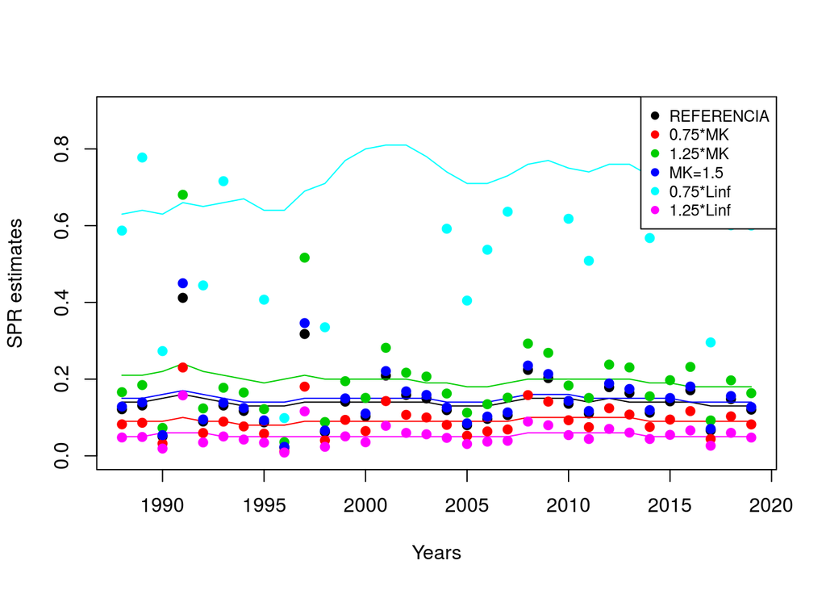

```r
plot(first(HkeLenFreq2Linf@Years):last(HkeLenFreq2Linf@Years),spr1,ylim=c(0,0.9),xlab="Years",ylab="SPR estimates",pch=19)

lines(first(HkeLenFreq2Linf@Years):last(HkeLenFreq2Linf@Years), smoothEsts1$SPR, lwd = 1,col="black")
lines(first(HkeLenFreq2Linf@Years):last(HkeLenFreq2Linf@Years), smoothEsts1MK$SPR, lwd = 1,col=2)
lines(first(HkeLenFreq2Linf@Years):last(HkeLenFreq2Linf@Years), smoothEsts2MK$SPR, lwd = 1,col=3)
lines(first(HkeLenFreq2Linf@Years):last(HkeLenFreq2Linf@Years), smoothEsts3MK$SPR, lwd = 1,col=4)
lines(first(HkeLenFreq2Linf@Years):last(HkeLenFreq2Linf@Years), smoothEsts1Linf$SPR, lwd = 1,col=5)
lines(first(HkeLenFreq2Linf@Years):last(HkeLenFreq2Linf@Years), smoothEsts2Linf$SPR, lwd = 1,col=6)


points(first(HkeLenFreq2Linf@Years):last(HkeLenFreq2Linf@Years), sprmk1,col=2,pch=19)
points(first(HkeLenFreq2Linf@Years):last(HkeLenFreq2Linf@Years), sprmk2,col=3,pch=19)
points(first(HkeLenFreq2Linf@Years):last(HkeLenFreq2Linf@Years), sprmk3,col=4,pch=19)
points(first(HkeLenFreq2Linf@Years):last(HkeLenFreq2Linf@Years), sprL1,col=5,pch=19)
points(first(HkeLenFreq2Linf@Years):last(HkeLenFreq2Linf@Years), sprL2,col=6,pch=19)

legend("topright", legend=c("REFERENCIA", "0.75*MK","1.25*MK","MK=1.5","0.75*Linf","1.25*Linf"),
       col=c("black", 2:6), pch=19, cex=0.8)
```

Gráfico F/M:

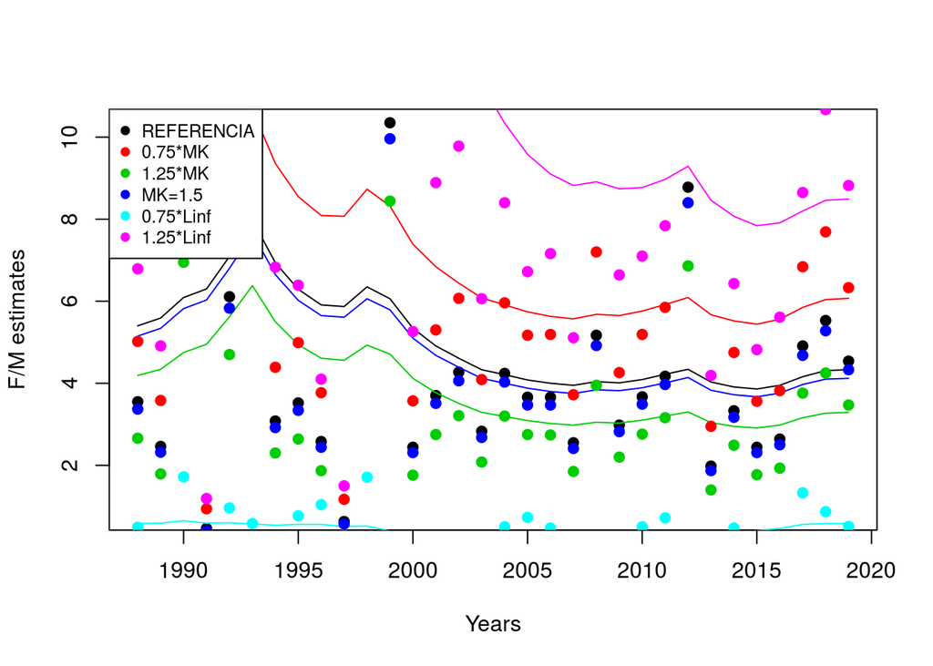

```r
fm1=Fit1@FM
fmmk1=Fit1MK@FM
fmmk2=Fit2MK@FM
fmmk3=Fit3MK@FM
fmL1=Fit1Linf@FM
fmL2=Fit2Linf@FM

plot(first(HkeLenFreq2Linf@Years):last(HkeLenFreq2Linf@Years),fm1,ylim=c(0.8,10.3),xlab="Years",ylab="F/M estimates",pch=19)

lines(first(HkeLenFreq2Linf@Years):last(HkeLenFreq2Linf@Years), smoothEsts1$FM, lwd = 1,col="black")
lines(first(HkeLenFreq2Linf@Years):last(HkeLenFreq2Linf@Years), smoothEsts1MK$FM, lwd = 1,col=2)
lines(first(HkeLenFreq2Linf@Years):last(HkeLenFreq2Linf@Years), smoothEsts2MK$FM, lwd = 1,col=3)
lines(first(HkeLenFreq2Linf@Years):last(HkeLenFreq2Linf@Years), smoothEsts3MK$FM, lwd = 1,col=4)
lines(first(HkeLenFreq2Linf@Years):last(HkeLenFreq2Linf@Years), smoothEsts1Linf$FM, lwd = 1,col=5)
lines(first(HkeLenFreq2Linf@Years):last(HkeLenFreq2Linf@Years), smoothEsts2Linf$FM, lwd = 1,col=6)


points(first(HkeLenFreq2Linf@Years):last(HkeLenFreq2Linf@Years), fmmk1,col=2,pch=19)
points(first(HkeLenFreq2Linf@Years):last(HkeLenFreq2Linf@Years), fmmk2,col=3,pch=19)
points(first(HkeLenFreq2Linf@Years):last(HkeLenFreq2Linf@Years), fmmk3,col=4,pch=19)
points(first(HkeLenFreq2Linf@Years):last(HkeLenFreq2Linf@Years), fmL1,col=5,pch=19)
points(first(HkeLenFreq2Linf@Years):last(HkeLenFreq2Linf@Years), fmL2,col=6,pch=19)

legend("topleft", legend=c("REFERENCIA", "0.75*MK","1.25*MK","MK=1.5","0.75*Linf","1.25*Linf"),
       col=c("black", 2:6), pch=19, cex=0.8)
```

CUIDADO Si 1.25* Linf es superior a la talla máxima observada tendréis el siguiente error.

```r
HkeLenFreq1@LMids
```

```
##  [1]  3.5  4.0  4.5  5.0  5.5  6.0  6.5  7.0  7.5  8.0  8.5  9.0  9.5 10.0 10.5
## [16] 11.0 11.5 12.0 12.5 13.0 13.5 14.0 14.5 15.0 15.5 16.0 16.5 17.0 17.5 18.0
## [31] 18.5 19.0 19.5 20.0
```

Si tomamos Linf igual a 130 se produce el error que podemos ver debajo.

```r
Hke2ParsLinf <-Hke1Pars
Hke2ParsLinf@Linf <- 130

HkeLenFreq2Linf <- new("LB_lengths", LB_pars=Hke2ParsLinf, file="LFreqSHake.csv", dataType="freq", header=TRUE)
HkeLenFreq2Linf@L_units <- Hke2ParsLinf@L_units


Fit2Linf <- LBSPRfit(Hke2ParsLinf, HkeLenFreq2Linf)
Error: Maximum length bin (129.5) can't be smaller than asymptotic size (130). Increase size of maximum length class ['maxL']
```

```r
HkeLenFreq2Linf@LMids=seq(3.5,24,0.5)#1:130
rows2add<-length(HkeLenFreq2Linf@LMids)-dim(HkeLenFreq2Linf@LData)[1]
B<-array(0,dim=c(rows2add,dim(HkeLenFreq2Linf@LData)[2]))
A=rbind(HkeLenFreq2Linf@LData,B)
#A[130,1:9]=rep(0,9)
tail(A)
HkeLenFreq2Linf@LData=A
Hke2ParsLinf <-Hke1Pars
Hke2ParsLinf@Linf <- 130
Fit2Linf <- LBSPRfit(Hke2ParsLinf, HkeLenFreq2Linf)
plotEsts(Fit2Linf)
```

[output not shown]